# credit card

jhk0530

2020 6 13

## 라이브러리 로드

```r
library(dplyr)
```

```r
library(ggplot2)
```

## 데이터 로드

- 데이터 출처 : [Kaggle Default of Credit Card Clients Dataset](https://www.kaggle.com/uciml/default-of-credit-card-clients-dataset/data)

```r
cards <- read.csv('UCI_Credit_Card.csv')
```

# 데이터 형태

데이터 항목은 총 25개로 다음과 같다.

## 고객 정보

1. ID : 각 고객 ID
2. LIMIT_BAL: 사용 가능한 Credit (NT dollar) (includes individual and family/supplementary credit
3. SEX: 성별 (1 = 남성, 2 = 여성)
4. EDUCATION: 교육 수준(1 = 대학원, 2 = 대졸, 3 = 고졸, 4 = 기타, 5 ~ 6 = 미상)
5. MARRIAGE: 기혼 상태 (1 = 기혼, 2 = 미혼, 3 = 기타)
6. AGE: 나이
7. default.payment.next.month: 지불 방식 (1 = 후불 , 0 = 선불?)

**이하 데이터는 전부 2005년 기준.**

## 상환 상태 (-1 : 완료, 그 외 숫자는 연체 기간, 9 이상은 9로 표기)

PAY_0: 9월 PAY_2: 8월 PAY_3: 7월 PAY_4: 6월 PAY_5: 5월 PAY_6: 4월

## 명세서 금액

BILL_AMT1: 9월 BILL_AMT2: 8월 BILL_AMT3: 7월 BILL_AMT4: 6월 BILL_AMT5: 5월 BILL_AMT6: 4월

## 이전 지불 금액

PAY_AMT1: 9월 PAY_AMT2: 8월 PAY_AMT3: 7월 PAY_AMT4: 6월 PAY_AMT5: 5월 PAY_AMT6: 4월

# 가능한 질문

Kaggle에 inspiration 으로 올라와있는 질문은 다음 2개이다.

1. 여러 특징에 따라 default payment가 얼마나 다른가 ?
2. default payment 를 가장 잘 설명하는 변수는 ?

대충 EDA나 varimplot 같은 걸로 충분히 결론이 나올 것 같은 내용들이다.

솔직히 이런게 무슨 의미가 있는지 잘 모르겠고,

1. 어떤 사람이 연체를 할까
2. 어떤 사람이 결제를 많이 하는 우량고객인가
3. 계절 별로 연관이 있나
4. 고객이 그룹화 되어 지는가

이 정도의 정보를 기대 할만 한 것 같다.

# 데이터 전처리 및 단순화

- 분석 하기 전에, 데이터를 손 봐야 할 필요가 있음.
- 예시로, 고객의 나이가 41세인지 42세인지 정말로 관심이 없다. 40대 혹은 40대 초반 이런식으로만 분류하면 충분.
- 데이터가 정밀 할수록 당연히 예측은 좋아지지만, 과도하게 정밀하면 overfit issue생김

## 1. ID : 그대로 둠

## 2. LIMIT_BAL : min : 10K, max = 1M, mean = 167K 니까

대충 10K ~ 20K, 20~40K, 40~60K, 60~80K, 80K~100K 이런식으로 등구간으로 나누려 했는데

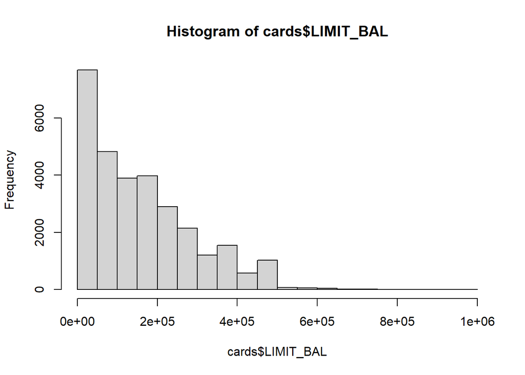

```r
hist(cards$LIMIT_BAL)
```

큰일 날뻔 했음.

```r
nrow(cards %>% filter(LIMIT_BAL > 500000)) # 206
```

```
## [1] 206
```

500K 이상은 전부 VIP로 간주 해도 충분함 (0.68%) 0.68%는 좀 안이뻐서 45K 이상 으로 수정( 4% )

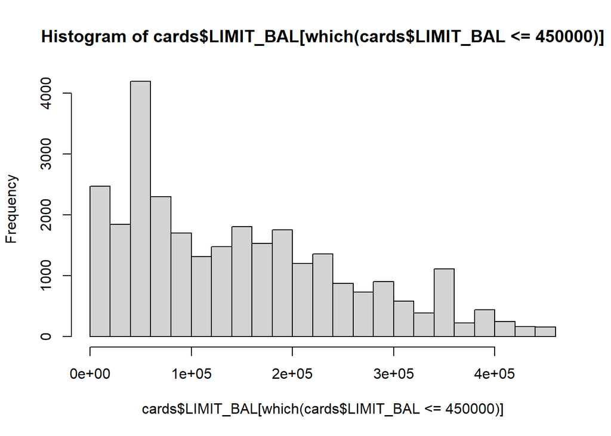

```r
vip_count <- nrow(cards %>% filter(LIMIT_BAL > 450000)) # 1231

hist(cards$LIMIT_BAL[which(cards$LIMIT_BAL<=450000)])
```

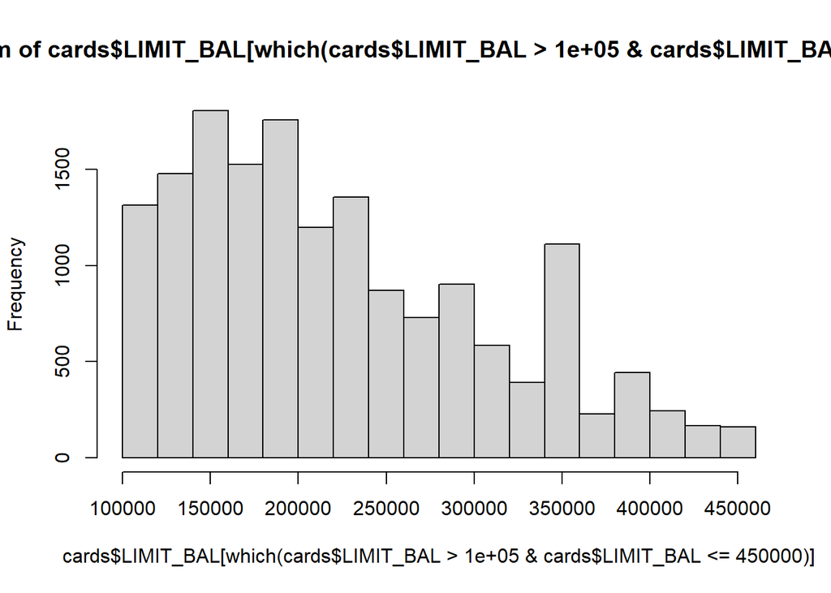

```r
hist(cards$LIMIT_BAL[which(cards$LIMIT_BAL>100000 & cards$LIMIT_BAL<=450000)])
```

이후 분포에서 100K 이하 사용자 : 라이트 그룹으로 간주 나머지 그룹에 대해서는 100K ~ 200K, 200K ~ 350K, 350K ~ 450K 로 나누면 충분.

단, 그룹을 1,2,3,4,5 처럼 숫자로 구분 지어버리면 안 됨

결론 아래 테이블처럼 5개 그룹으로 나눔, 이후 factor 처리

| 그룹 | 수치 |
| --- | --- |
| A | 0~100K |
| B | 100~200K |
| C | 200~350K |
| D | 350~450K |
| E | 450K~1000K |

```r
group_lim_balance <- function(i){
  if(i<100000){return('A')}
  if(i<200000){return('B')}
  if(i<350000){return('C')}
  if(i<450000){return('D')}
  return('E')
}

cards$LIMIT_BAL <- sapply(cards$LIMIT_BAL, group_lim_balance)
cards$LIMIT_BAL <- as.factor(cards$LIMIT_BAL)
```

## 3. SEX : factorize

```r
describe_sex <- function(i){
  if(i=='1') return('M')
  return('F')
}
cards$SEX <- sapply(cards$SEX, describe_sex)
cards$SEX <- as.factor(cards$SEX)
```

## 4. EDUCATION : 미상 및 기타 삭제 처리 후 (1%), factorize

```r
nrow(cards %>% filter(EDUCATION > 3))
```

```
## [1] 454
```

```r
cards <- cards %>% filter(EDUCATION < 4)
nrow(cards) # 29546
```

```
## [1] 29546
```

```r
describe_edu <- function(i){
  if(i=='1') return('G')
  if(i=='2') return('U')
  return('H')
}

cards$EDUCATION <- sapply(cards$EDUCATION, describe_edu)
cards$EDUCATION <- as.factor(cards$EDUCATION)
```

```r
nrow(cards %>% filter(MARRIAGE ==3) )
```

```
## [1] 315
```

```r
describe_mar <- function(i){
  if(i=='1'){return('O')}
  return('X')
}

cards$MARRIAGE <- sapply(cards$MARRIAGE, describe_mar)
cards$MARRIAGE <- as.factor(cards$MARRIAGE)
```

## 6. AGE

나이를 10 대 단위로 조율 할까 하다가, 11살의 초4와, 19살의 고3을. 20살의 1학년과 29살의 대학원생을 같은 그룹에 묶는 건 매우 실례 같아서

5 단위로 나누기로 함, 단 60대 이상은 전부 통일

```r
describe_age <- function(i){
  if(i > 60){return("6S")}
  if(i > 55){return('5O')}
  if(i > 50){return('5Y')}
  if(i > 45){return('4O')}
  if(i > 40){return('4Y')}
  if(i > 35){return('3O')}
  if(i > 30){return('3Y')}
  if(i > 25){return('2O')}
  if(i > 20){return('2Y')}
}
cards$AGE <- sapply(cards$AGE, describe_age)
cards$AGE <- as.factor(cards$AGE)
```

## 7. Defalt.payment.next.month : 변수 명 변경후 ( payment ), factorize

```r
colnames(cards)[25] <- 'PAYMENT'
describe_pay <- function(i){
  if(i==0)return("F")
  return("T")
}
cards$PAYMENT <- as.factor(cards$PAYMENT)
```

## 8. 상환 상태 PAY_0 ~ PAY_6

- 값들 중에 -1, -2, 0 은 그냥 ‘NONE’ 으로 통일 ( 연체 없음 )
- 1을 제외하고 (1회성 연체 : ‘ONCE’), 나머지 값은 통일 (‘DELAY’)

```r
describe_delay <- function(i){
  if(i < 1){return('NONE')}
  if(i == 1){return("ONCE")}
  return("DELAY")
}

for(i in 7:12){
  cards[,i] <- sapply(cards[,i], describe_delay)
}
```

- 상환 상태를 단순화 했다고는 하지만, 결국 6개월 치 인것은 똑같음.
- 심도 있는 단순화를 위해, 이를 clustering을 하기로 함
- 문제는, factor (“ONCE”, “NONE”, “DELAY”)라서 euclidean distance를 사용 할 수 없다는 것
- 아쉬운 대로, 6개의 sequence에 대해서, 아래의 식으로 distance를 계산 하기로 함

$if(x_i==y_i) : dist = dist$

$else : dist +1$

```r
nrow(cards)
```

```
## [1] 29546
```

- 문제는 30000 * 30000 matrix는 매우, 매우 size가 큼 (7.2G)
- 이를 위해 sparse Matrix 사용하려고 했으나 마찬가지로 계산이 expensive한것은 똑같음.
- 아예 unique를 씌워서 sequence를 구분 하기로 함

```r
uniq_pattern <- unique(cards[,7:12])
nrow(uniq_pattern)
```

```
## [1] 92
```

```r
head(uniq_pattern)
```

```
##    PAY_0 PAY_2 PAY_3 PAY_4 PAY_5 PAY_6
## 1  DELAY DELAY  NONE  NONE  NONE  NONE
## 2   NONE DELAY  NONE  NONE  NONE DELAY
## 3   NONE  NONE  NONE  NONE  NONE  NONE
## 9   NONE  NONE DELAY  NONE  NONE  NONE
## 12  NONE  NONE  NONE  NONE  NONE DELAY
## 14  ONCE DELAY DELAY  NONE  NONE DELAY
```

그 결과 총 92개의 패턴이 발생 즉, 30000개에 할 필요 없이 92*92 만 하면 됨

```r
distobj <- matrix(0,nrow(uniq_pattern), nrow(uniq_pattern))

mydist <- function(x,y){
  d <- 0
  for(i in 1:length(x)){
    if(x[i]!=y[i]) d <- d + 1
  }
  return(d)
}

for(i in 1:nrow(uniq_pattern)){
  for(j in 1:nrow(uniq_pattern)){
    if(i > j){distobj[i,j] <- distobj[j,i]}

    distobj[i,j] = mydist(uniq_pattern[i,], uniq_pattern[j,])
  }
}

head(distobj)
```

```
##      [,1] [,2] [,3] [,4] [,5] [,6] [,7] [,8] [,9] [,10] [,11] [,12] [,13] [,14]
## [1,]    0    2    2    3    3    3    1    6    2     4     1     3     4     5
## [2,]    2    0    2    3    1    2    2    4    3     4     3     3     5     3
## [3,]    2    2    0    1    1    4    2    4    1     4     1     1     5     5
## [4,]    3    3    1    0    2    3    3    3    2     5     2     2     4     4
## [5,]    3    1    1    2    0    3    3    3    2     3     2     2     6     4
## [6,]    3    2    4    3    3    0    2    4    3     5     4     5     3     3
##      [,15] [,16] [,17] [,18] [,19] [,20] [,21] [,22] [,23] [,24] [,25] [,26]
## [1,]     4     4     1     3     3     1     4     3     3     5     3     2
## [2,]     4     2     3     4     3     1     4     5     1     3     4     2
## [3,]     6     2     3     2     1     3     2     5     3     3     4     2
## [4,]     5     3     2     3     2     4     3     4     4     4     3     3
## [5,]     5     1     4     3     2     2     3     6     2     2     5     1
## [6,]     3     4     2     4     5     2     6     4     3     5     2     3
##      [,27] [,28] [,29] [,30] [,31] [,32] [,33] [,34] [,35] [,36] [,37] [,38]
```

[output cut: 41 more lines]

```r
distobj <- as.dist(distobj)
```

이를 h-clustering에 사용

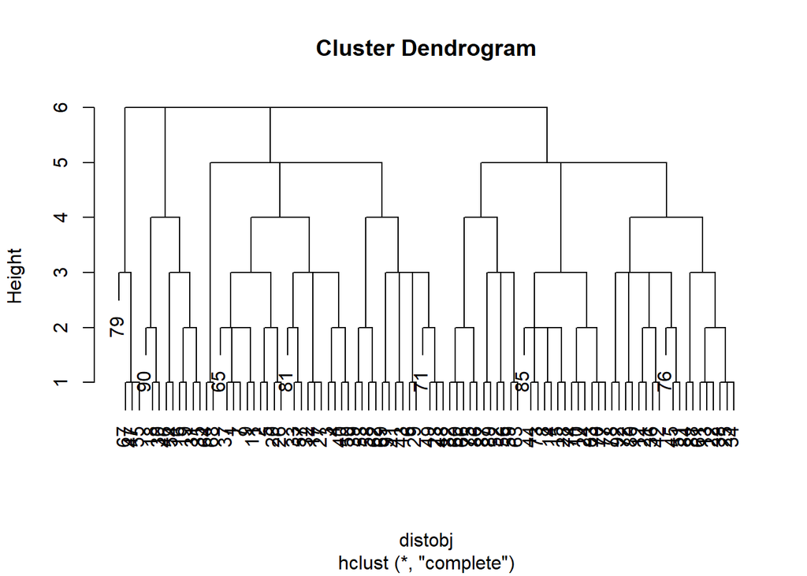

```r
hc <- hclust(distobj)
plot(hc)
```

샘플 수가 작은 순으로 표기

```r
uniq_pattern[which(cutree(hc, h = 0.9)==4),]
```

```
##   PAY_0 PAY_2 PAY_3 PAY_4 PAY_5 PAY_6
## 9  NONE  NONE DELAY  NONE  NONE  NONE
```

11375는 distance가 허접해서 섞인 경우라 오류긴 한데, 이 경우는 한번 한번 밀리다가 장기 연체가 되는 편

```r
uniq_pattern[which(cutree(hc, h = 0.9)==3),]
```

```
##   PAY_0 PAY_2 PAY_3 PAY_4 PAY_5 PAY_6
## 3  NONE  NONE  NONE  NONE  NONE  NONE
```

```r
uniq_pattern[which(cutree(hc, h = 0.9)==1),]
```

```
##   PAY_0 PAY_2 PAY_3 PAY_4 PAY_5 PAY_6
## 1 DELAY DELAY  NONE  NONE  NONE  NONE
```

더 들여다 보면 재밌는 결과가 나올 것 같긴 한데, 원래 목적은 6개월 상환 내용을 단순화 하려는 것 이었기 때문에, 이 부분에 대한 분석은 중단 후 그냥 unique_pattern을 바탕으로 단순화해서 넣기로 함.

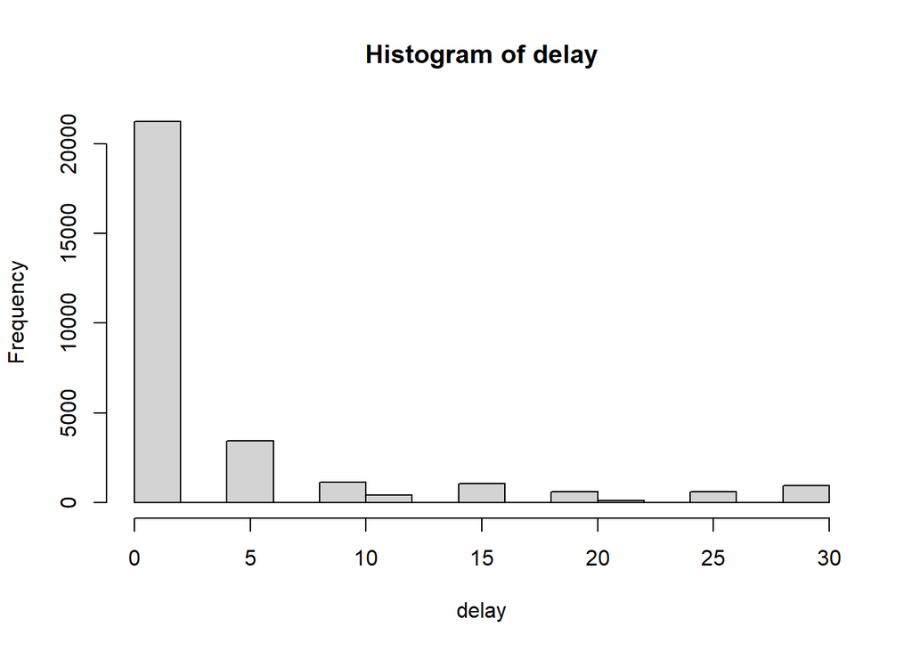

```r
describe_delay2 <- function(i){
  S <- 0
  S <- S + length(which(i=='ONCE'))
  S <- S + length(which(i=='DELAY'))*5
  return(S)
}

delay <- sapply(1:nrow(cards), function(i){describe_delay2(cards[i,7:12])})

hist(delay)
```

delay 는 크게 3 그룹으로 분류 가능

1. 0점 (우량)
2. 5점 이하 (양호)
3. 10점 이상 (주의)

이에 따라 6개 항목 치환

```r
describe_delay3 <- function(i){
  if(i == 0)return('A')
  if(i <= 5) return('B')
  return('C')
}

delay <- sapply(delay, describe_delay3)
delay <- as.factor(delay)
cards$DELAY <- delay
cards <- cards[,-c(7:12)]
```

## 9. 명세서 금액 BILL_AMT1 ~ BILL_AMT6

```r
summary(cards[,7:12])
```

```
##    BILL_AMT1         BILL_AMT2        BILL_AMT3         BILL_AMT4
##  Min.   :-165580   Min.   :-69777   Min.   :-157264   Min.   :-170000
##  1st Qu.:   3540   1st Qu.:  2980   1st Qu.:   2658   1st Qu.:   2333
##  Median :  22250   Median : 21062   Median :  20035   Median :  19008
##  Mean   :  50868   Mean   : 48885   Mean   :  46747   Mean   :  43079
##  3rd Qu.:  66431   3rd Qu.: 63327   3rd Qu.:  59718   3rd Qu.:  53979
##  Max.   : 964511   Max.   :983931   Max.   :1664089   Max.   : 891586
##    BILL_AMT5        BILL_AMT6
##  Min.   :-81334   Min.   :-339603
##  1st Qu.:  1782   1st Qu.:   1285
##  Median : 18092   Median :  17120
##  Mean   : 40206   Mean   :  38830
##  3rd Qu.: 50021   3rd Qu.:  49106
##  Max.   :927171   Max.   : 961664
```

명세서 금액이 -인 경우는 뭔지 잘 모르겠다. 카드 환불인가? 전산 오류?

이 쪽은 별 관심이 없으므로, 데이터에서 bill이 0이하 의 값이 있는 데이터를 0으로 치환 함. 사실 버려도 상관은 없다.

```r
for(i in 7:12){
  cards[which(cards[,i]<0),i] <- 0
}
```

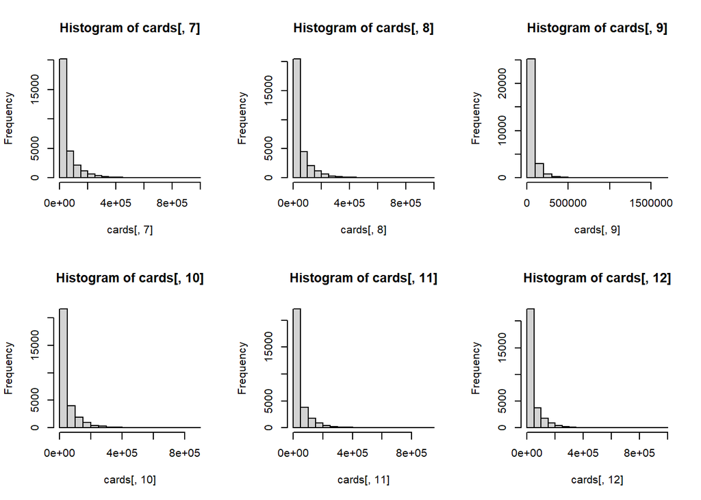

```r
par(mfrow = c(2,3))
hist(cards[,7])
hist(cards[,8])
hist(cards[,9])
hist(cards[,10])
hist(cards[,11])
hist(cards[,12])
```

```r
par(mfrow = c(1,1))
```

명세서 금액의 경우는 대부분 소액 (5K 이하)이며 그 외에는 유의미한 차이를 보이지 않는 대형 결제 라고 봐도 무방할 것 같다. 그러나, 50K이상의 초대형 결제가 있기 때문에, 해당 그룹 포함 4개로 나누기로 함

```r
describe_bill <- function(i){
  if(i==0) return("A")
  if(i <= 5000) return("B")
  if(i <= 50000) return("C")
  return("D")
}

for(i in 7:12){
  cards[,i] <- sapply(cards[,i],describe_bill)
  cards[,i] <- as.factor(cards[,i])
}

summary(cards[,7:12])
```

```
##  BILL_AMT1 BILL_AMT2 BILL_AMT3 BILL_AMT4 BILL_AMT5 BILL_AMT6
##  A: 2557   A: 3123   A: 3462   A: 3790   A: 4065   A: 4588
##  B: 5741   B: 5502   B: 5325   B: 5249   B: 5473   B: 5525
##  C:11939   C:11904   C:12177   C:12632   C:12614   C:12227
##  D: 9309   D: 9017   D: 8582   D: 7875   D: 7394   D: 7206
```

분류가 잘못 된 것 같다. 0 , 소형, 대형, 초대형으로 나누면 얼추 비슷 할 줄 알았는데 대형이 좀 과하게 많다. 이 경우 data 자체에 categorical bias가 생길 수도 있다. 물론 대형 고객을 더 고려하는게 필요 하다 라고 포장 하면 되므로, 묻고 간다.

위에서 했던 것처럼, categorical 에 주관적인 weight을 줘서 한 항목으로 합친다

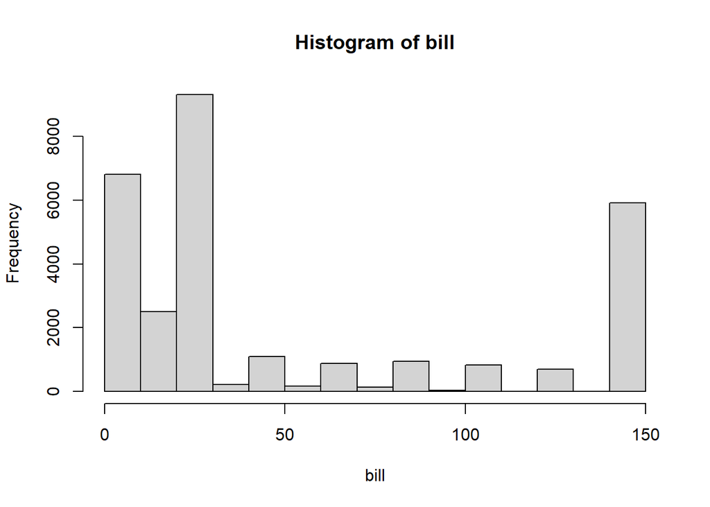

```r
describe_bill2 <- function(i){
  S <- 0
  S <- S + length(which(i=='B'))
  S <- S + length(which(i=='C'))*5
  S <- S + length(which(i=='D'))*25
  return(S)
}

bill <- sapply(1:nrow(cards), function(i){describe_bill2(cards[i,7:12])})

hist(bill)
```

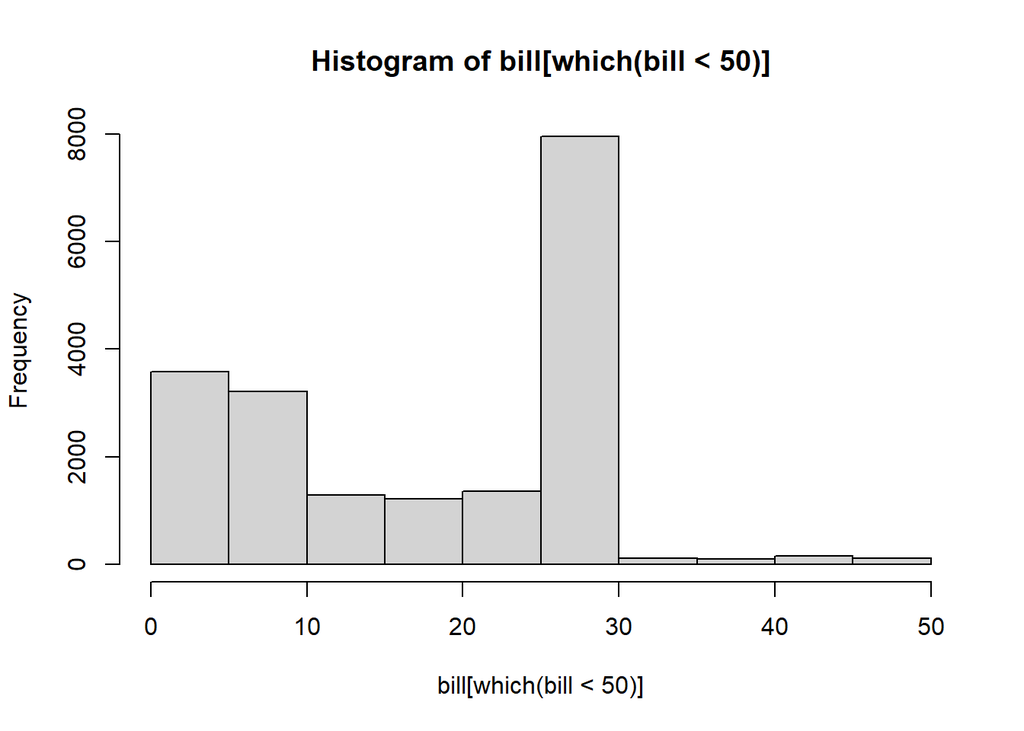

```r
hist(bill[which(bill < 50)])
```

0, ~ 10, ~ 30, 이외 의 구간으로 그룹을 나눔

```r
describe_bill3 <- function(i){
  if(i == 0) return('A')
  if(i <= 10) return('B')
  if(i <= 30) return('C')
  return('D')
}

bill <- sapply(bill, describe_bill3)
bill <- as.factor(bill)
cards$BILL <- bill
cards <- cards[,-c(7:12)]

summary(cards)
```

```
##        ID        LIMIT_BAL SEX       EDUCATION MARRIAGE       AGE
##  Min.   :    1   A:11325   F:17820   G:10585   O:13429   2O     :7042
##  1st Qu.: 7466   B: 7257   M:11726   H: 4931   X:16117   3Y     :5712
##  Median :14934   C: 7421             U:14030             3O     :4844
##  Mean   :14961   D: 2169                                 2Y     :3814
##  3rd Qu.:22450   E: 1374                                 4Y     :3549
##  Max.   :30000                                           4O     :2352
##                                                          (Other):2233
##     PAY_AMT1           PAY_AMT2            PAY_AMT3         PAY_AMT4
##  Min.   :     0.0   Min.   :      0.0   Min.   :     0   Min.   :     0
##  1st Qu.:   996.2   1st Qu.:    821.5   1st Qu.:   390   1st Qu.:   299
##  Median :  2100.0   Median :   2005.0   Median :  1800   Median :  1500
##  Mean   :  5654.5   Mean   :   5889.7   Mean   :  5178   Mean   :  4823
##  3rd Qu.:  5004.0   3rd Qu.:   5000.0   3rd Qu.:  4500   3rd Qu.:  4010
##  Max.   :873552.0   Max.   :1684259.0   Max.   :896040   Max.   :621000
##
##     PAY_AMT5         PAY_AMT6        PAYMENT   DELAY     BILL
##  Min.   :     0   Min.   :     0.0   0:22943   A:19548   A:  953
##  1st Qu.:   264   1st Qu.:   133.2   1: 6603   B: 4398   B: 5847
##  Median :  1500   Median :  1500.0             C: 5600   C:11806
##  Mean   :  4784   Mean   :  5178.6                       D:10940
##  3rd Qu.:  4027   3rd Qu.:  4000.0
##  Max.   :426529   Max.   :528666.0
##
```

## 10. 이전 지불 금액 : 데이터에 관심이 없다. 이미 연체로 필요한 정보는 있기 때문에 그냥 삭제함

```r
cards <- cards %>% select(ID, LIMIT_BAL, SEX, EDUCATION, MARRIAGE, AGE, PAYMENT, DELAY, BILL)
```

# linear modeling

긴 데이터 전처리가 끝났다. 30000 X 25에서 29546 X 9로 ,

```r
summary(cards)
```

```
##        ID        LIMIT_BAL SEX       EDUCATION MARRIAGE       AGE
##  Min.   :    1   A:11325   F:17820   G:10585   O:13429   2O     :7042
##  1st Qu.: 7466   B: 7257   M:11726   H: 4931   X:16117   3Y     :5712
##  Median :14934   C: 7421             U:14030             3O     :4844
##  Mean   :14961   D: 2169                                 2Y     :3814
##  3rd Qu.:22450   E: 1374                                 4Y     :3549
##  Max.   :30000                                           4O     :2352
##                                                          (Other):2233
##  PAYMENT   DELAY     BILL
##  0:22943   A:19548   A:  953
##  1: 6603   B: 4398   B: 5847
##            C: 5600   C:11806
##                      D:10940
##
##
##
```

이제 원래 하고자 했던 질문을 다시 보자

1. 어떤 사람이 연체를 할까
2. 어떤 사람이 결제를 많이 하는 우량고객인가
3. 계절 별로 연관이 있나
4. 고객이 그룹화 되어 지는가

연체 (DELAY)는 B 혹은 C인지만 구분 하면 됨.

문제는 categorical data는 그대로 쓰긴 어렵고 numerical 하게 다시 바꿔야 함.

## 1. 연체 : 나이, 결혼, 교육, 성별, 자산

```r
Q1 <- cards %>% select(LIMIT_BAL, EDUCATION, MARRIAGE, AGE, DELAY)
summary(Q1)
```

```
##  LIMIT_BAL EDUCATION MARRIAGE       AGE       DELAY
##  A:11325   G:10585   O:13429   2O     :7042   A:19548
##  B: 7257   H: 4931   X:16117   3Y     :5712   B: 4398
##  C: 7421   U:14030             3O     :4844   C: 5600
##  D: 2169                       2Y     :3814
##  E: 1374                       4Y     :3549
##                                4O     :2352
##                                (Other):2233
```

```r
Q1$LIMIT_BAL <- as.numeric(Q1$LIMIT_BAL)
Q1$EDUCATION <- as.numeric(Q1$EDUCATION)
Q1$MARRIAGE <- as.numeric(Q1$MARRIAGE)
Q1$AGE <- as.numeric(Q1$AGE)
Q1$DELAY <- as.numeric(Q1$DELAY)
set.seed(20200613)
idx <- sample(1:nrow(Q1), size = nrow(Q1)/2)
Q1train <- Q1[idx,]
Q1test <- Q1[idx,]

fm <- lm(DELAY ~ ., Q1train)

summary(fm)
```

```
##
## Call:
## lm(formula = DELAY ~ ., data = Q1train)
##
## Residuals:
##     Min      1Q  Median      3Q     Max
## -0.7537 -0.5798 -0.3717  0.4703  1.9760
##
## Coefficients:
##               Estimate Std. Error t value Pr(>|t|)
## (Intercept)  1.9481475  0.0381724  51.035  < 2e-16 ***
## LIMIT_BAL   -0.1678570  0.0057188 -29.352  < 2e-16 ***
## EDUCATION    0.0059756  0.0072807   0.821  0.41180
## MARRIAGE    -0.0441398  0.0140710  -3.137  0.00171 **
## AGE         -0.0004237  0.0033503  -0.126  0.89937
## ---
## Signif. codes:  0 '***' 0.001 '**' 0.01 '*' 0.05 '.' 0.1 ' ' 1
##
## Residual standard error: 0.7717 on 14768 degrees of freedom
## Multiple R-squared:  0.0594, Adjusted R-squared:  0.05915
## F-statistic: 233.2 on 4 and 14768 DF,  p-value: < 2.2e-16
```

p-value 기준, EDUCTION과 AGE는 별 연관이 없다고 한다

plot 결과도 마찬가지

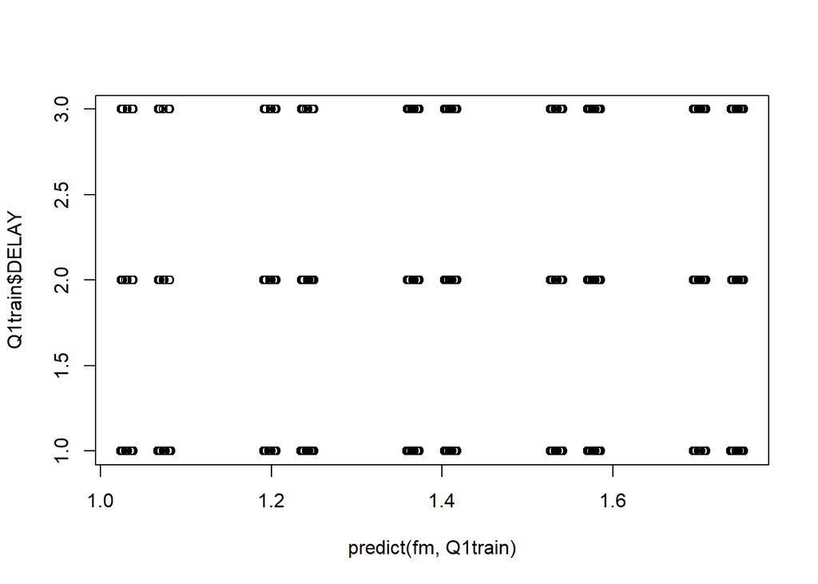

```r
plot(predict(fm, Q1train), Q1train$DELAY)
```

왜지 ?, 이유를 알지 못하는 상태에서 2 3번을 하는건 의미가 없을 것 같다.

# EDA로 보자 그냥

## 연체, 나이, 결혼, 교육, 자산의 관계

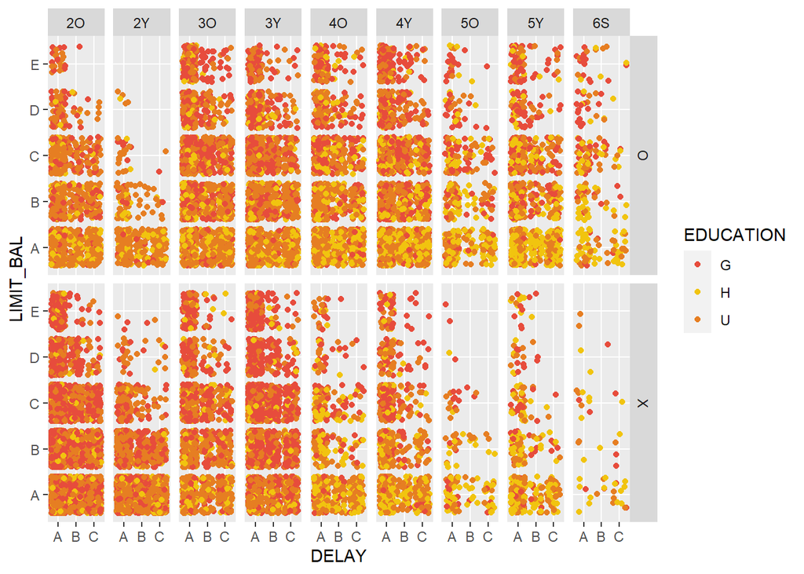

```r
ggplot(data = cards, aes(x = DELAY, y = LIMIT_BAL, colour = EDUCATION)) +
  geom_jitter() +
  facet_grid(MARRIAGE~AGE) +
  scale_color_manual(values = c('#e74c3c', '#f1c40f', '#e67e22'))
```

결과 설명

- X축, DELAY 가 A 일수록 좋고,
- Y축, 은 위로 갈 수록 고자산.
- 색상(EDUCATION) 은 진할 수록 고학력.
- 우측 O,X 는 기혼 여부.

찾은 insight

1. 고학력 -> 결혼 안함.
2. 고자산 -> 연체 줄어듬.
3. 자산 분포는 20대 초반에 제일 적다가, 점차 늘어나며 50대 초반 이후로 줄어드는 경향.
4. 학력과 자산은 비례하는 것처럼 보임. (아래로 갈수록 색 연함)
5. 미혼의 경우, 20대 후반 ~ 30대 초반까지 연체율 높음.
6. 기혼의 경우, 30대 초반 ~ 40대 초반까지 연체율 높음.

## 결제양, 자산, 지불방식, 성별 의 관계

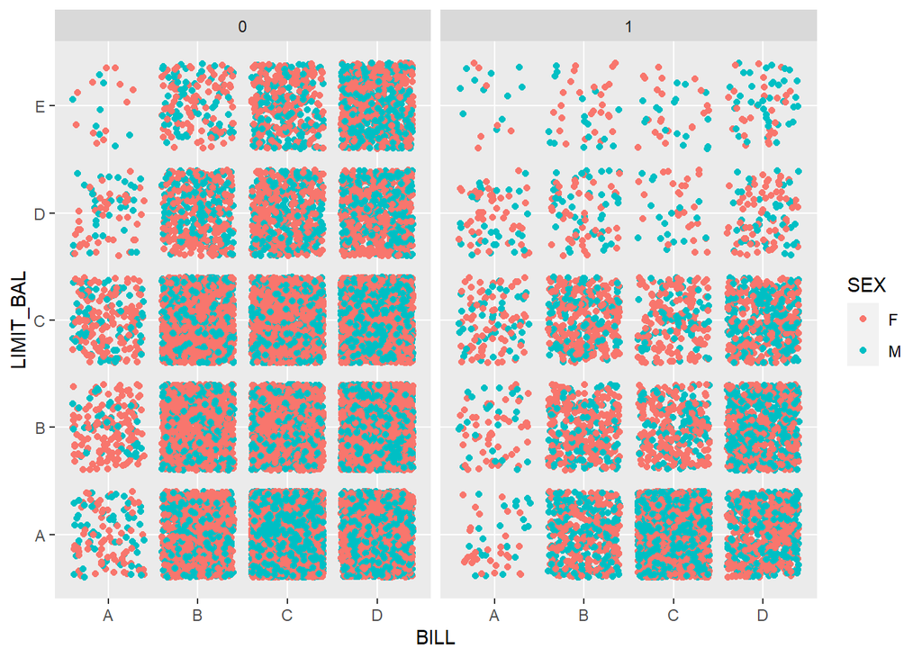

```r
ggplot(data = cards, aes(x = BILL, y = LIMIT_BAL, colour = SEX)) +
  geom_jitter() +
  facet_grid( ~ PAYMENT)
```

결과 설명

찾은 insight

1. 성별에 따라 연관 없어보임.
2. 대부분 체크 카드를 많이 사용
3. 신용 카드의 경우, 저 자산 - 중형 거래에 많이 쓰임 (우측 A,C)
4. 체크 카드는 전 범위에 골고루 쓰임

# 결론

1. 어떤 사람이 연체를 할까

저학력, 저자산, 미혼 + 2후 3초 , 기혼 + 3초 4초

2. 어떤 사람이 결제를 많이 하는 우량 고객인가

고자산 일 줄 알았지만, 그것과는 관계 없음. 전혀

3. 계절 별로 연관이 있나

데이터 단순화 과정에서 사라짐

4. 고객이 그룹화 되어 지는가

연체 패턴을 바탕으로 92개 그룹으로 나눠지는 것 확인함.

끝